# Tutorial: Function and usage panelmap

Arshi Arora

## Motivation

Let’s see a demonstration examples from the $mtcars$ datasets.

Performing data exploration by groups or between two variables can be done by boxplot or correlation plots. Let’s see a boxplot between variables `mpg` and `cyl`, and a correlation plot between all the variables of `mtcars` dataset.

We see how `mpg` decreases as number of `cyl` increases. The same relationship can also be seen in the correlation plot at column 8, row 4.

This can get tedious, and a more visually appealing approach is required to understand the relationship between the variables at a glance.

```r
print(kable(head(mtcars), "html", caption="mtcars dataset") %>%
        kable_styling(bootstrap_options = "striped", full_width = F,position="left"))
```

mtcars dataset

|  | mpg | cyl | disp | hp | drat | wt | qsec | vs | am | gear | carb |
| --- | --- | --- | --- | --- | --- | --- | --- | --- | --- | --- | --- |
| Mazda RX4 | 21.0 | 6 | 160 | 110 | 3.90 | 2.620 | 16.46 | 0 | 1 | 4 | 4 |
| Mazda RX4 Wag | 21.0 | 6 | 160 | 110 | 3.90 | 2.875 | 17.02 | 0 | 1 | 4 | 4 |
| Datsun 710 | 22.8 | 4 | 108 | 93 | 3.85 | 2.320 | 18.61 | 1 | 1 | 4 | 1 |
| Hornet 4 Drive | 21.4 | 6 | 258 | 110 | 3.08 | 3.215 | 19.44 | 1 | 0 | 3 | 1 |
| Hornet Sportabout | 18.7 | 8 | 360 | 175 | 3.15 | 3.440 | 17.02 | 0 | 0 | 3 | 2 |
| Valiant | 18.1 | 6 | 225 | 105 | 2.76 | 3.460 | 20.22 | 1 | 0 | 3 | 1 |

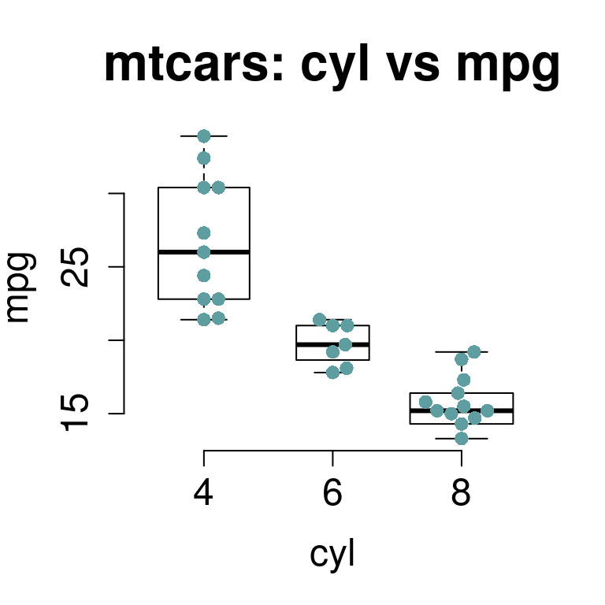

```r
#mtcars: mpg vs cyl
boxplot(mpg ~ cyl, data =mtcars, outline = FALSE, main = 'mtcars: cyl vs mpg', varwidth=T, cex.axis=1.5, cex.main=2, frame.plot=F,  xlab="cyl", ylab="mpg", cex.lab=1.5)
beeswarm(mpg ~ cyl, data = mtcars, col = "cadetblue", pch = 16,cex=1.2, add = TRUE)
```

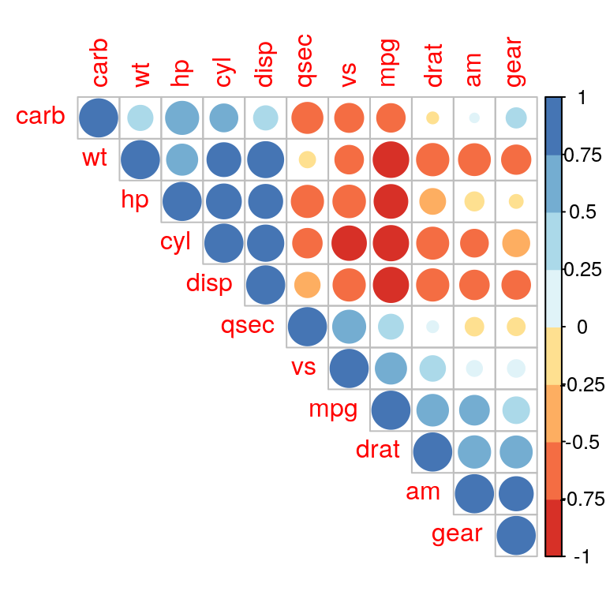

```r
#or a correlation plot
M <-cor(mtcars)
corrplot(M, type="upper", order="hclust",col=brewer.pal(n=8, name="RdYlBu"))
```

```r
soln.col = pal_nejm("default")(7)
```

## Example 1

We will illustrate *panlemap* by sorting mtcars data according to variable `cyl` and plotting `mpg, vs, am` and `gear` to understand the relationship between them.

panelmap table

|  | 4 | 6 | 8 | RowTotal | pval |
| --- | --- | --- | --- | --- | --- |
| mpg | 26[21.4-33.9] | 19.7[17.8-21.4] | 15.2[10.4-19.2] |  | P<0.0001 |
| NA | 0 | 0 | 0 |  |  |
| vs |  |  |  |  | P<0.0001 |
| 0 | 1(9%) | 3(43%) | 14(100%) | 18(56.25%) |  |
| 1 | 10(91%) | 4(57%) | 0(0%) | 14(43.75%) |  |
| am |  |  |  |  | 0.0091 |
| 0 | 3(27%) | 4(57%) | 12(86%) | 19(59.38%) |  |
| 1 | 8(73%) | 3(43%) | 2(14%) | 13(40.62%) |  |
| gear |  |  |  |  | P<0.0001 |
| 3 | 1(9%) | 2(29%) | 12(86%) | 15(46.88%) |  |
| 4 | 8(73%) | 4(57%) | 0(0%) | 12(37.5%) |  |
| 5 | 2(18%) | 1(14%) | 2(14%) | 5(15.62%) |  |

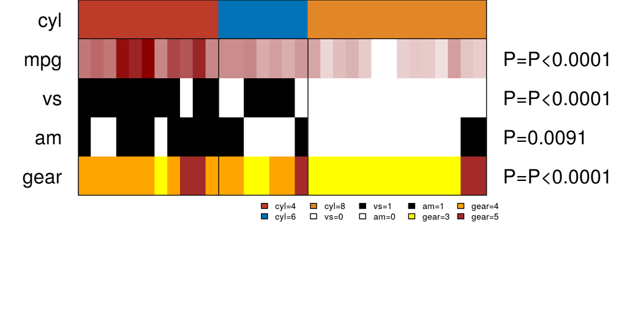

```r
#mtcars
#sort everything by cyl
mtcars.sort = mtcars[order(mtcars$cyl),]

#other features to plot
mat = mtcars.sort[,c("mpg","vs","am","gear")]

#color assigned to each feature
mat.col=list(am=c("white","black"), vs=c("white","black"), gear=c("yellow","orange","brown"), mpg=c("white", "darkred"))

#type of each feature. type=1 for discrete and type=2 for continuous.
mat.type= c(2,1,1,1)
tab=makepanel(soln=mtcars.sort$cyl, soln.name="cyl",soln.col=soln.col[1:3], mat=mat, mat.col=mat.col, mat.type=mat.type, border=TRUE, legend=TRUE, get.pval=TRUE, cex=1.5)
print(kable(tab, "html", caption="panelmap table") %>%
        kable_styling(bootstrap_options = "striped", full_width = F,position="left"))
```

All this at one look!

To compare it with the full correlation matrix, we plot all the features.

**Taking more features**

```r
#taking more features
mat.col=list(am=c("white","black"), vs=c("white","black"), gear=c("yellow","orange","brown"), mpg=c("white", "darkred"), disp=c("white", "black"), hp=c("white","black"), drat = c("white", "black"), wt=c("white", "darkblue"), carb=brewer.pal(n=6, name="BuGn") )

mat = mtcars.sort[,names(mat.col)]

#type of each feature. type=1 for discrete and type=2 for continuous.
mat.type=c(1,1,1,2,2,2,2,2,1)
tab=makepanel(soln=mtcars.sort$cyl, soln.name="cyl",soln.col=soln.col[1:3], mat=mat, mat.col=mat.col, mat.type=mat.type, border=TRUE, legend=TRUE, get.pval=TRUE,lncol=8,lwd=2, cex=1.5, lcex=1.5)
```

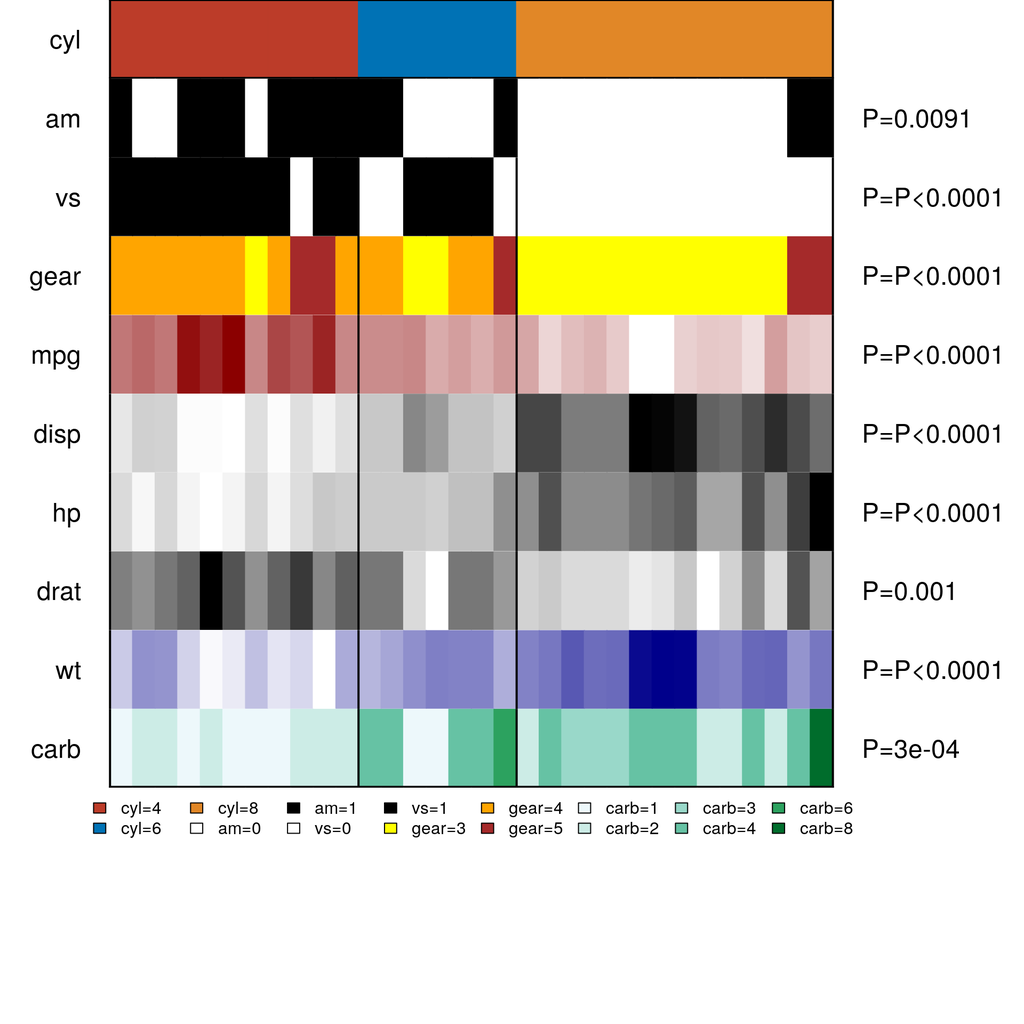

## Functions and Usage

There are three core functions of `panelmap`.

### panelet_group

Given a solution, make a group panelet. Let `cyl` variable with values 4,6 and 8 be our group variable from package `mtcars`. Let’s assign the colors `red`, `blue` and `green` to its values as follows :-

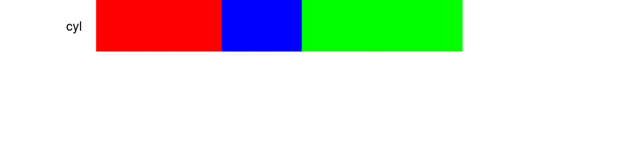

```r
#adjust margins and number of panelet values
par(mfrow=c(3,1),mar=c(0,8,0,14))

#sort the entire data frame according to the group solution you are interested in
mtcars.sort = mtcars[order(mtcars$cyl),]

#plot group
tt=panelet_group(soln=mtcars.sort$cyl, soln.col=c("red","blue","green"),soln.name="cyl",cex=1, border=FALSE, legend=FALSE)
```

`cex` controls the magnification of text labels on the left-hand side and is passed as part of `(...)`. Other relevant parameters that can be passed are `col` - to change color of text labels. `lty` and `lwd` to change border line type and magnification, as in baseR. `border` and `legend` take logical values and their default value is `FALSE`.

Once we have a group panelet, we can start plotting other variables of interest.

### panelet_category

This function plots discrete data type. Usage - `function(pp,pp.col,soln, var.n="var.n"`

`NA.flag=FALSE, NA.col="grey", get.pval=FALSE, border=FALSE, border.col="black", legend=FALSE,...)`

These are the default values to the function. There is an option to assign a color for `NAs` in the data by using `NA.flag` and `NA.col`. User can also control the color of border colors by `border.col`

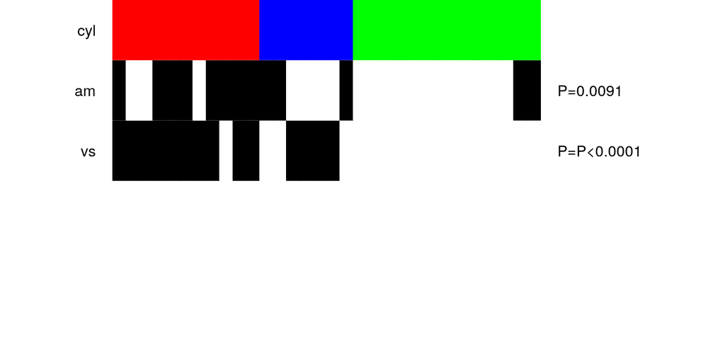

```r
#adjust margins and number of panelet values
par(mfrow=c(6,1),mar=c(0,8,0,14))

#sort the entire data frame according to the group solution you are interested in
mtcars.sort = mtcars[order(mtcars$cyl),]

#plot group
tt=panelet_group(soln=mtcars.sort$cyl, soln.col=c("red","blue","green"),soln.name="cyl",cex=1, border=FALSE, legend=FALSE)

#plot variable am
tt=panelet_category(pp=mtcars.sort$am, pp.col=c("white", "black"), soln=mtcars.sort$cyl, var.n="am", get.pval=TRUE)

#plot variable vs
tt=panelet_category(mtcars.sort$vs, c("white", "black"), mtcars.sort$cyl, "vs", get.pval=TRUE)
```

`panelet_category` also returns the summary of the variable with respect to the group variable along with an association test.

### panelet_continuous

This function provides a gradient of the values present in the continuous variable. Note that this function plots a gradient and assigns colors relative to the range and magnitude of values in the variable. If the values are a mix of negative and positive values the gradient might look biased and lack in contrast. We will try to address this in a future functionality.

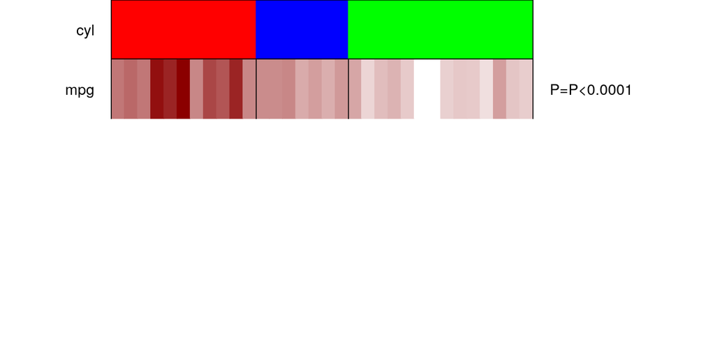

```r
#adjust margins and number of panelet values
par(mfrow=c(6,1),mar=c(0,8,0,14))

#sort the entire data frame according to the group solution you are interested in
mtcars.sort = mtcars[order(mtcars$cyl),]

#plot group
tt=panelet_group(soln=mtcars.sort$cyl, soln.col=c("red","blue","green"),soln.name="cyl",cex=1, border=TRUE, legend=FALSE)

#plot variable mpg
tt =panelet_continuous(mtcars.sort$mpg, pp.col=c("white","darkred"), soln=mtcars.sort$cyl,var.n="mpg",NA.flag=FALSE, get.pval=TRUE, border=TRUE)
```

### makepanel

`makepanel` is a wrapper function that outputs a legend, an association table and the panelmap, all with one command. You need to provide the meta information of your data set like, colors, data type, labels color etc. See Example 1

## Other features

### custom visualizations

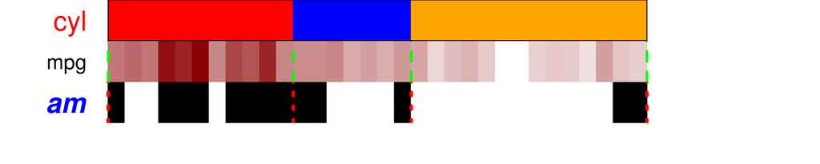

```r
#adjust margins and number of panelet values
par(mfrow=c(4,1),mar=c(0,8,0,14))
#sort the entire data frame according to the group solution you are interested in

#use sorted mtcars
#plot group
tt=panelet_group(soln=mtcars.sort$cyl, soln.col=c("red","blue","orange"),soln.name="cyl", cex=2, col="red", border=TRUE)

#plot variable mpg
tt =panelet_continuous(mtcars.sort$mpg, pp.col=c("white","darkred"), soln=mtcars.sort$cyl,var.n="mpg", cex=1.5, col="black", border=TRUE,border.col="green", lwd=3, lty=2)

tt=panelet_category(pp=mtcars.sort$am, pp.col=c("white", "black"), soln=mtcars.sort$cyl, var.n="am", cex=2, col="blue", border=TRUE,border.col="red", lwd=4, lty=3, font=4)
```

### handle NAs or missing data

```r
am.na = mtcars.sort$am
am.na[c(1,10,20,30)] = NA
mtcars.sort$am.na = am.na
mat = mtcars.sort[,c("vs","am","am.na","gear")]
mat.col=list(am=c("white","black"), am.na=c("white", "black"), vs=c("white","black"), gear=c("yellow","orange","brown"))

mat.type= c(1,1,1,1)
tab=makepanel(soln=mtcars.sort$cyl, soln.name="cyl",soln.col=soln.col[1:3], mat=mat, mat.col=mat.col, mat.type=mat.type, border=TRUE, legend=TRUE, get.pval=TRUE, cex=1.7, NA.flag=TRUE, NA.col="grey",lncol = 7, lcex=1.3)

print(kable(tab, "html", caption="panelmap NA examaple") %>%
        kable_styling(bootstrap_options = "striped", full_width = F,position="left"))
```

panelmap NA examaple

|  | 4(n=11;34.38%) | 6(n=7;21.88%) | 8(n=14;43.75%) | RowTotal | pval |
| --- | --- | --- | --- | --- | --- |
| vs |  |  |  |  | P<0.0001 |
| 0 | 1(9%) | 3(43%) | 14(100%) | 18(56.25%) |  |
| 1 | 10(91%) | 4(57%) | 0(0%) | 14(43.75%) |  |
| am |  |  |  |  | 0.0091 |
| 0 | 3(27%) | 4(57%) | 12(86%) | 19(59.38%) |  |
| 1 | 8(73%) | 3(43%) | 2(14%) | 13(40.62%) |  |
| am.na |  |  |  |  | 0.0707 |
| 0 | 3(27%) | 4(57%) | 10(71%) | 17(53.12%) |  |
| 1 | 6(55%) | 3(43%) | 2(14%) | 11(34.38%) |  |
| NA | 2(18%) | 0(0%) | 2(14%) | 4(12.5%) |  |
| gear |  |  |  |  | P<0.0001 |
| 3 | 1(9%) | 2(29%) | 12(86%) | 15(46.88%) |  |
| 4 | 8(73%) | 4(57%) | 0(0%) | 12(37.5%) |  |
| 5 | 2(18%) | 1(14%) | 2(14%) | 5(15.62%) |  |

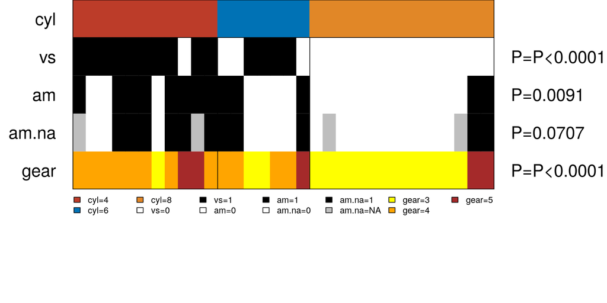

See how there are grey bars in panelet row **am.na** corresponding to NA at values 1,10,20 and 30.